# RESPONSI 1 STA1211 PENGENALAN R

# Instalasi R dan RStudio

R merupakan bahasa pemrograman berbasis objek yang *open source* yang sudah banyak digunakan untuk analisis statistik dan *Data Science*. Beberapa kelebihan R diantaranya mudah dalam melakukan transformasi dan pemrosesan data, tersedia banyak *packages*, mampu menghasilkan berbagai grafik yang bagus, dan aplikasi interaktif/ dashboard berbasis web.

R dapat didownload [disini](https://cran.r-project.org)

Tampilan RGUI

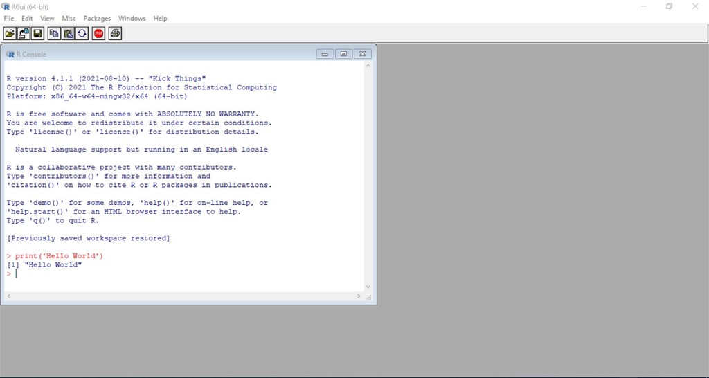

Berbeda dari R, RStudio is *Integrated Development Environment* (IDE) untuk R.

RStudio dapat didownload [disini](https://www.rstudio.com/products/rstudio/download/)

Tampilan RStudio

[figure not shown]

Untuk menegetikkan perintah dalam RStudio dilakukan di bagian **Editor** atau **Console**.

Membuat R Script baru:

[figure not shown]

# Objek di R

## Vector

Vektor merupakan objek satu dimensi. Untuk membuat objek berupa vektor dengan menggunakan fungsi `c(…)`, `seq(…)`, `rep(…)`, `paste(…)`. Fungsi `c()` untuk membuat vektor dengan element sesuai yang diinginkan

```r
a1<-c(2,4,1,6,3,8,6)
a1
```

```
## [1] 2 4 1 6 3 8 6
```

```r
assign("a2",c("2","4","7","3"))
a2
```

```
## [1] "2" "4" "7" "3"
```

Fungsi `seq()` untuk membuat baris bilangan.

```r
a3 <- seq(1,10,by=0.5)
a3
```

```
##  [1]  1.0  1.5  2.0  2.5  3.0  3.5  4.0  4.5  5.0  5.5  6.0  6.5  7.0  7.5  8.0
## [16]  8.5  9.0  9.5 10.0
```

```r
a4 <- seq(1,10,length.out=15)
a4
```

```
##  [1]  1.000000  1.642857  2.285714  2.928571  3.571429  4.214286  4.857143
##  [8]  5.500000  6.142857  6.785714  7.428571  8.071429  8.714286  9.357143
## [15] 10.000000
```

Fungsi `rep()` untuk membuat bilangan berulang.

```r
a5 <- rep(1,5)
a5
```

```
## [1] 1 1 1 1 1
```

```r
a6 <- rep(1:5,2)
a6
```

```
##  [1] 1 2 3 4 5 1 2 3 4 5
```

```r
a7 <- rep(1:3,1:3)
a7
```

```
## [1] 1 2 2 3 3 3
```

```r
a8 <- rep(1:3,rep(2,3))
a8
```

```
## [1] 1 1 2 2 3 3
```

```r
a9 <- rep(1:3,each=2)
a9
```

```
## [1] 1 1 2 2 3 3
```

Fungsi `paste()` untuk membuat membuat karakter berpola

```r
a10 <- paste("A",1:10,sep="")
a10
```

```
##  [1] "A1"  "A2"  "A3"  "A4"  "A5"  "A6"  "A7"  "A8"  "A9"  "A10"
```

```r
a11 <- paste0("A",1:10)
a11
```

```
##  [1] "A1"  "A2"  "A3"  "A4"  "A5"  "A6"  "A7"  "A8"  "A9"  "A10"
```

```r
a12 <- paste("A",1:10,sep="-")
a12
```

```
##  [1] "A-1"  "A-2"  "A-3"  "A-4"  "A-5"  "A-6"  "A-7"  "A-8"  "A-9"  "A-10"
```

```r
a13 <- paste0("B",a8)
a13
```

```
## [1] "B1" "B1" "B2" "B2" "B3" "B3"
```

Mengakses vektor atau slicing elemen vektor dengan menggunakan operator `[]`. Sedangkan fungsi `length()` untuk mengetahui panjang vector/ jumlah elemen keseluruhan dari vektor.

```r
a2[3]
```

```
## [1] "7"
```

```r
a3[10:15]
```

```
## [1] 5.5 6.0 6.5 7.0 7.5 8.0
```

```r
a10[c(4,7,9)]
```

```
## [1] "A4" "A7" "A9"
```

```r
a13[-c(1:2)]
```

```
## [1] "B2" "B2" "B3" "B3"
```

```r
length(a4)
```

```
## [1] 15
```

### Latihan 1

```r
c("la","ye")[rep(c(1,2,2,1),times=4)]
```

```
##  [1] "la" "ye" "ye" "la" "la" "ye" "ye" "la" "la" "ye" "ye" "la" "la" "ye" "ye"
## [16] "la"
```

```r
c("la","ye")[rep(rep(1:2,each=3),2)]
```

```
##  [1] "la" "la" "la" "ye" "ye" "ye" "la" "la" "la" "ye" "ye" "ye"
```

Pada sintax pertama berisi perintah membuat vektor yang berisi “la” dan “ye” yang diulang 4 kali dengan urutan 1 (“la”) 2 (“ye”) 2 (“ye”) 1 (“la”). Pada sintax kedua berisi perintah membuat vektor yang berisi “la” dan “ye” diulang 2 kali dengan urutan 1(“la”) 2(“ye”) masing-masing 3 kali.

### Latihan 2

Sintax yang menghasilkan output sebagai berikut: X1 Y2 X3 Y4 X5 Y6 X7 Y8 X9 Y10

```r
paste0(c('X','Y'),1:10)
```

```
##  [1] "X1"  "Y2"  "X3"  "Y4"  "X5"  "Y6"  "X7"  "Y8"  "X9"  "Y10"
```

Sintax yang menghasilkan output sebagai berikut: 1 4 7 10 13 16 19 22 25 28

```r
seq(1,28, by=3)
```

```
##  [1]  1  4  7 10 13 16 19 22 25 28
```

## Matrix

Matriks merupakan objek 2 dimensi, yaitu memiliki baris dan kolom. Untuk membuat object matrik menggunakan fungsi `matrix(...,m,n)` dengan m jumlah baris dan n jumlah kolom, `dim(vector)<-c(m,n)`, `rbind()`, `cbind()`

```r
a14 <- 1:12
b1 <- matrix(a14,3,4)
b1
```

```
##      [,1] [,2] [,3] [,4]
## [1,]    1    4    7   10
## [2,]    2    5    8   11
## [3,]    3    6    9   12
```

```r
b2 <- matrix(a14,3,4,byrow=TRUE)
b2
```

```
##      [,1] [,2] [,3] [,4]
## [1,]    1    2    3    4
## [2,]    5    6    7    8
## [3,]    9   10   11   12
```

Argument byrow=TRUE membuat element matriks diisi per baris, jika semua element baris pertama (semua kolom) sudah terisi lanjut ke baris berikutnya. Pada matriks b1 element matriks diisi per kolom

```r
b3 <- matrix(1:10,4,4)
b3
```

```
##      [,1] [,2] [,3] [,4]
## [1,]    1    5    9    3
## [2,]    2    6   10    4
## [3,]    3    7    1    5
## [4,]    4    8    2    6
```

```r
b4 <- matrix(1:10,4,5)
b4
```

```
##      [,1] [,2] [,3] [,4] [,5]
## [1,]    1    5    9    3    7
## [2,]    2    6   10    4    8
## [3,]    3    7    1    5    9
## [4,]    4    8    2    6   10
```

Pada b3 muncul warning karena jumlah data tidak sesuai dengan dimensi matriks. Jika ukuran data yang akan menjadi element matriks tidak sesuai dengan dimensi matriks maka element matriks akan diulang dari data yang pertama. Suatu vektor dapat diubah menjadi matriks.

```r
b5 <- a14
dim(b5)<-c(6,2)
b5
```

```
##      [,1] [,2]
## [1,]    1    7
## [2,]    2    8
## [3,]    3    9
## [4,]    4   10
## [5,]    5   11
## [6,]    6   12
```

Untuk membuat matriks persegi dengan memberi 1 argument setelah argument data.

```r
b6 <- matrix(1:4,2)
b6
```

```
##      [,1] [,2]
## [1,]    1    3
## [2,]    2    4
```

```r
b7 <- matrix(6:9,2)
b7
```

```
##      [,1] [,2]
## [1,]    6    8
## [2,]    7    9
```

Untuk menggabungkan beberapa matriks menggunakan `cbind()` dan `rbind()`. `cbind()` untuk menggabungkan kolom, sedangkan `rbind()` untuk menggabungkan baris.

```r
b8 <- rbind(b6,b7)
b8
```

```
##      [,1] [,2]
## [1,]    1    3
## [2,]    2    4
## [3,]    6    8
## [4,]    7    9
```

```r
b9 <- cbind(b7,b6)
b9
```

```
##      [,1] [,2] [,3] [,4]
## [1,]    6    8    1    3
## [2,]    7    9    2    4
```

Untuk mengetahui dimensi (jumlah baris dan jumlah kolom) suatu matriks dengan menggunakan fungsi `dim()`. Sedangkan fungsi `length()` dalam matriks untuk mengetahui total element matriks(jumlah baris x jumlah kolom).

```r
dim(b8)
```

```
## [1] 4 2
```

```r
dim(b9)
```

```
## [1] 2 4
```

```r
dim(a14)
```

[output not shown]

```r
length(b3)
```

```
## [1] 16
```

Untuk mengakses element matriks/ slicing menggunakan operator `[]`

```r
b2[2,3]
```

```
## [1] 7
```

Sintax di atas untuk mengakses element pada baris ke 2 kolom ke 3

```r
b2[2,2:4]
```

```
## [1] 6 7 8
```

```r
b2[1:2,]
```

```
##      [,1] [,2] [,3] [,4]
## [1,]    1    2    3    4
## [2,]    5    6    7    8
```

```r
#mengakses baris 1 dan 3 untuk semua kolom kecuali kolom ke 2
b2[c(1,3),-2]
```

```
##      [,1] [,2] [,3]
## [1,]    1    3    4
## [2,]    9   11   12
```

```r
b2[4]
```

```
## [1] 2
```

Sintax di atas untuk mengakses element ke 4. Urutan element pada suatu matriks dihitung dari baris 1 kolom 1, baris 2 kolom 1 dan seterusnya.

## Array

Array merupakan objek multi dimensi. Dimensi dari suatu array adalah baris, kolom, dan halaman/layer serta terkadang buku. Untuk membuat object array menggunakan fungsi `array(...,dim=c())`

```r
c1 <- array(a14,dim=c(2,2,3))
c1
```

```
## , , 1
##
##      [,1] [,2]
## [1,]    1    3
## [2,]    2    4
##
## , , 2
##
##      [,1] [,2]
## [1,]    5    7
## [2,]    6    8
##
## , , 3
##
##      [,1] [,2]
## [1,]    9   11
## [2,]   10   12
```

Sintax di atas menghasilkan suatu array yang terdiri dari 2 baris, 2 kolom dan 3 layer.

```r
c2 <- array(a14,dim=c(2,1,2,3))
c2
```

```
## , , 1, 1
##
##      [,1]
## [1,]    1
## [2,]    2
##
## , , 2, 1
##
##      [,1]
## [1,]    3
## [2,]    4
##
## , , 1, 2
##
##      [,1]
## [1,]    5
## [2,]    6
##
## , , 2, 2
##
##      [,1]
## [1,]    7
## [2,]    8
##
## , , 1, 3
##
##      [,1]
## [1,]    9
## [2,]   10
##
## , , 2, 3
##
##      [,1]
## [1,]   11
## [2,]   12
```

Sintax di atas menghasilkan suatu array yang terdiri dari 2 baris, 1 kolom, 2 layer dan 3 buku. Suatu matriks merupakan array 1 layer.

```r
c4 <- array(a14,dim=c(3,4))
c4
```

```
##      [,1] [,2] [,3] [,4]
## [1,]    1    4    7   10
## [2,]    2    5    8   11
## [3,]    3    6    9   12
```

```r
c5<- array(a14)
c5
```

```
##  [1]  1  2  3  4  5  6  7  8  9 10 11 12
```

Untuk mengakses element array sama dengan vector maupun matriks dengan operator `[]`.

```r
c2[,,1,]
```

```
##      [,1] [,2] [,3]
## [1,]    1    5    9
## [2,]    2    6   10
```

Sintax di atas untuk mengakses element matriks layer 1 untuk semua baris, semua kolom dan semua buku.

```r
c2[,,,2]
```

```
##      [,1] [,2]
## [1,]    5    7
## [2,]    6    8
```

Sintax di atas untuk mengakses semua element di buku ke 2.

```r
c2[,,1,3]
```

```
## [1]  9 10
```

Sintax di atas untuk mengakses element di layer pertama buku ke 3

## Factor

Faktor adalah tipe object kategori. Untuk membuat object factor menggunakan fungsi `factor()`, `ordered(...,levels=c())`

```r
a15 <- c("A","B","AB","O")
d1 <- factor(a15)
d1
```

```
## [1] A  B  AB O
## Levels: A AB B O
```

Secara default levels dari object factor diurutkan berdasarkan alfabet. Untuk mengubah urutan levels dalam faktor dengan menambah argument levels diikuti urutan level yang diinginkan saat membuat object faktor.

```r
d2 <- factor(a15,levels=c("O","A","B","AB"))
d2
```

```
## [1] A  B  AB O
## Levels: O A B AB
```

d2 memiliki urutan levels O,A,B,AB sesuai dengan input yang diberikan.

```r
a16 <- c("SD","SMP","SMA","SARJANA","MAGISTER")
d3 <- ordered(a16)
d3
```

```
## [1] SD       SMP      SMA      SARJANA  MAGISTER
## Levels: MAGISTER < SARJANA < SD < SMA < SMP
```

Fungsi `ordered()` untuk membuat suatu object factor yang memiliki urutan (skala pengukuran ordinal). Secara default rutan berdasarkan alpabet.

```r
d4 <- ordered(a16, levels=a16)
d4
```

```
## [1] SD       SMP      SMA      SARJANA  MAGISTER
## Levels: SD < SMP < SMA < SARJANA < MAGISTER
```

```r
d5 <- factor(a16, levels=a16, ordered=TRUE)
d5
```

```
## [1] SD       SMP      SMA      SARJANA  MAGISTER
## Levels: SD < SMP < SMA < SARJANA < MAGISTER
```

Kedua sintax di atas menghasilkan output yang sama yaitu object factor yang memiliki urutan (skala pengukuran ordinal). Untuk mengakses element factor sama dengan object yang lain.

```r
d1[2]
```

```
## [1] B
## Levels: A AB B O
```

```r
d4[2:3]
```

```
## [1] SMP SMA
## Levels: SD < SMP < SMA < SARJANA < MAGISTER
```

## List

List merupakan kumpulan object, baik object dari class yang sama maupun berbeda. Untuk membuat object list menggunakan fungsi `list()`.

```r
e1 <- list(a1,b2,c1,d2)
e1
```

```
## [[1]]
## [1] 2 4 1 6 3 8 6
##
## [[2]]
##      [,1] [,2] [,3] [,4]
## [1,]    1    2    3    4
## [2,]    5    6    7    8
## [3,]    9   10   11   12
##
## [[3]]
## , , 1
##
##      [,1] [,2]
## [1,]    1    3
## [2,]    2    4
##
## , , 2
##
##      [,1] [,2]
## [1,]    5    7
## [2,]    6    8
##
## , , 3
##
##      [,1] [,2]
## [1,]    9   11
## [2,]   10   12
##
##
## [[4]]
## [1] A  B  AB O
## Levels: O A B AB
```

Output dari sintax di atas adalah object list dengan index elementnya default yaitu bilangan 1,2,3,dst

```r
e2 <- list(vect=a1,mat=b2,array=c1,fac=d2)
e2
```

```
## $vect
## [1] 2 4 1 6 3 8 6
##
## $mat
##      [,1] [,2] [,3] [,4]
## [1,]    1    2    3    4
## [2,]    5    6    7    8
## [3,]    9   10   11   12
##
## $array
## , , 1
##
##      [,1] [,2]
## [1,]    1    3
## [2,]    2    4
##
## , , 2
##
##      [,1] [,2]
## [1,]    5    7
## [2,]    6    8
##
## , , 3
##
##      [,1] [,2]
## [1,]    9   11
## [2,]   10   12
##
##
## $fac
## [1] A  B  AB O
## Levels: O A B AB
```

Output dari sintax di atas adalah object list dengan index elementnya adalah vect, mat, array dan fac.

Untuk mengakses element list menggunakan operator `[]` atau `[[]]` jika index element berupa bilangan dan operator `$` jika index bukan bilangan.

```r
e1[[1]]
```

```
## [1] 2 4 1 6 3 8 6
```

```r
e1[2]
```

```
## [[1]]
##      [,1] [,2] [,3] [,4]
## [1,]    1    2    3    4
## [2,]    5    6    7    8
## [3,]    9   10   11   12
```

```r
e2$fac
```

```
## [1] A  B  AB O
## Levels: O A B AB
```

```r
e2[2]
```

```
## $mat
##      [,1] [,2] [,3] [,4]
## [1,]    1    2    3    4
## [2,]    5    6    7    8
## [3,]    9   10   11   12
```

```r
e1[c(2,4)]
```

```
## [[1]]
##      [,1] [,2] [,3] [,4]
## [1,]    1    2    3    4
## [2,]    5    6    7    8
## [3,]    9   10   11   12
##
## [[2]]
## [1] A  B  AB O
## Levels: O A B AB
```

Suatu object list tidak memiliki dimensi seperti vector, tetapi hanya memiliki length. Untuk mengetahui nama index pada list menggunakan fungsi `names()`.

```r
dim(e2)
```

[output not shown]

```r
length(e2)
```

```
## [1] 4
```

```r
names(e2)
```

```
## [1] "vect"  "mat"   "array" "fac"
```

## Data Frame

Data Frame merupakan objek berupa tabel.

```r
a17 <- 11:15
d5 <- factor(LETTERS[6:10])
e3<-c('hp','tv','koran','laptop','radio')
f1 <- data.frame(d5,a17,e3)
f1
```

```
##   d5 a17     e3
## 1  F  11     hp
## 2  G  12     tv
## 3  H  13  koran
## 4  I  14 laptop
## 5  J  15  radio
```

Output dari sintax di atas adalah sebuah dataframe dengan element kolom pertama adalah data d5 (huruf ke 6 sampai 10 yaitu F,G,H,I,J), kolom kedua adalah data a17 (angka 11 sampai 15) dan kolom ketiga data e3.

Slicing element dataframe menggunakan operator `[]` atau `$`

```r
f1[1,3]
```

```
## [1] "hp"
```

```r
f1[3,]
```

```
##   d5 a17    e3
## 3  H  13 koran
```

```r
f1$d5[4]
```

```
## [1] I
## Levels: F G H I J
```

```r
f1[,"a17"]
```

```
## [1] 11 12 13 14 15
```

Untuk mengetahui nama kolom-kolom dalam dataframe menggunakan fungsi `colnames()`. Sedangkan untuk mengetahui sruktur data dari dataframe menggunakan fungsi `srt()`.

```r
colnames(f1)
```

```
## [1] "d5"  "a17" "e3"
```

```r
str(f1)
```

```
## 'data.frame':    5 obs. of  3 variables:
##  $ d5 : Factor w/ 5 levels "F","G","H","I",..: 1 2 3 4 5
##  $ a17: int  11 12 13 14 15
##  $ e3 : chr  "hp" "tv" "koran" "laptop" ...
```

Untuk mengetahui ringkasan data dari dataframe menggunakan fungsi `summary()`. Jika dalam dataframe terdapat data integer maka akan ditampilkan beberapa ringkasan statistik seperti mean, median, min, max.

```r
summary(f1)
```

```
##  d5         a17          e3
##  F:1   Min.   :11   Length:5
##  G:1   1st Qu.:12   Class :character
##  H:1   Median :13   Mode  :character
##  I:1   Mean   :13
##  J:1   3rd Qu.:14
##        Max.   :15
```

### Latihan 3

Seorang peneliti merancang sebuah perancangan percobaan RAKL dengan 4 perlakuan dan 3 kelompok (anggaplah respon percobaan berupa baris bilangan). Bantulah peneliti tersebut untuk membuat raw data

```r
perl<-factor(rep(paste0("P",1:4),each=3))
kel<-factor(rep(1:3,4))
Resp<-seq(1,23, by=2)
raw.data<-data.frame(perl,kel,Resp)
raw.data
```

```
##    perl kel Resp
## 1    P1   1    1
## 2    P1   2    3
## 3    P1   3    5
## 4    P2   1    7
## 5    P2   2    9
## 6    P2   3   11
## 7    P3   1   13
## 8    P3   2   15
## 9    P3   3   17
## 10   P4   1   19
## 11   P4   2   21
## 12   P4   3   23
```

Jika ragu dengan class suatu object dan ingin mengetahui apakah class object sesuai dugaan dengan menggunakan `fungsi is.__()`

```r
is.array(c4)
```

```
## [1] TRUE
```

```r
is.data.frame(d2)
```

```
## [1] FALSE
```

```r
is.factor(d3)
```

```
## [1] TRUE
```

```r
is.list(e2)
```

```
## [1] TRUE
```

```r
is.matrix(a12)
```

```
## [1] FALSE
```

```r
is.vector(a2)
```

```
## [1] TRUE
```

Jika ingin mengubah class suatu data ke class yang lain menggunakan fungsi `as.__()`.

```r
e4<-as.factor(e3)
e4
```

```
## [1] hp     tv     koran  laptop radio
## Levels: hp koran laptop radio tv
```

```r
a18<-as.matrix(a5)
a18
```

```
##      [,1]
## [1,]    1
## [2,]    1
## [3,]    1
## [4,]    1
## [5,]    1
```

```r
c7<-as.list(c1)
c7
```

```
## [[1]]
## [1] 1
##
## [[2]]
## [1] 2
##
## [[3]]
## [1] 3
##
## [[4]]
## [1] 4
##
## [[5]]
## [1] 5
##
## [[6]]
## [1] 6
##
## [[7]]
## [1] 7
##
## [[8]]
## [1] 8
##
## [[9]]
## [1] 9
##
## [[10]]
## [1] 10
##
## [[11]]
## [1] 11
##
## [[12]]
## [1] 12
```

```r
b10<-as.data.frame(b2)
b10
```

```
##   V1 V2 V3 V4
## 1  1  2  3  4
## 2  5  6  7  8
## 3  9 10 11 12
```

**Ilustrasi perbedaan objek di R**

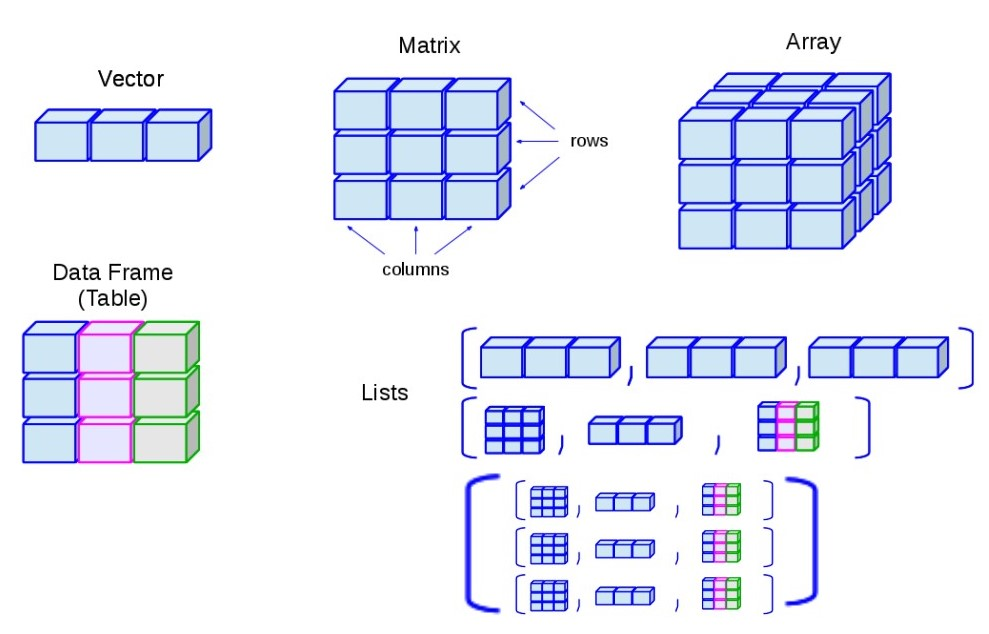